# **E-news Express A/B Testing**

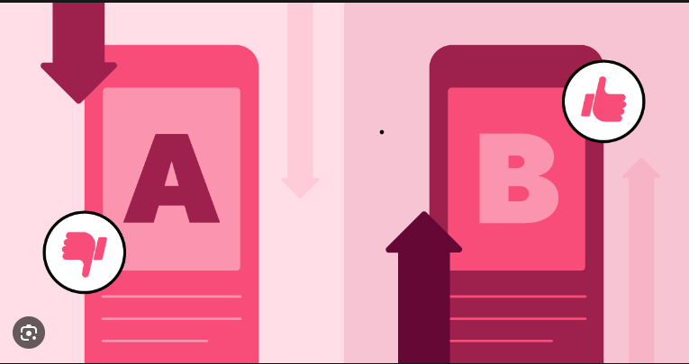

The design team of the **E-news Express, an online news portal**, has researched and created a new landing page that has a new outline & more relevant content shown compared to the old page. In order to test the effectiveness of the new landing page in gathering new subscribers, the Data Science team conducted an experiment by randomly selecting 100 users and dividing them equally into two groups. The existing landing page was served to the first group (control group) and the new landing page to the second group (treatment group). Data regarding the interaction of users in both groups with the two versions of the landing page was collected.

Let us import the data set for further analysis:

```python
#setup for data analysis
import numpy as np
import pandas as pd
import matplotlib.pyplot as plt
import seaborn as sns
%matplotlib inline

%cd C:\Users\ajays\Dropbox\PGP-AIML\projects\enewsexpress
```

```
C:\Users\ajays\Dropbox\PGP-AIML\projects\enewsexpress
```

## Exploratory Data Analysis

```python
abtest = pd.read_csv('abtest.csv')
abtest.head()
```

|  | user_id | group | landing_page | time_spent_on_the_page | converted | language_preferred |
| --- | --- | --- | --- | --- | --- | --- |
| 0 | 546592 | control | old | 3.48 | no | Spanish |
| 1 | 546468 | treatment | new | 7.13 | yes | English |
| 2 | 546462 | treatment | new | 4.40 | no | Spanish |
| 3 | 546567 | control | old | 3.02 | no | French |
| 4 | 546459 | treatment | new | 4.75 | yes | Spanish |

```python
abtest.shape
```

```
(100, 6)
```

```python
abtest.info()
```

```
<class 'pandas.core.frame.DataFrame'>
RangeIndex: 100 entries, 0 to 99
Data columns (total 6 columns):
 #   Column                  Non-Null Count  Dtype
---  ------                  --------------  -----
 0   user_id                 100 non-null    int64
 1   group                   100 non-null    object
 2   landing_page            100 non-null    object
 3   time_spent_on_the_page  100 non-null    float64
 4   converted               100 non-null    object
 5   language_preferred      100 non-null    object
dtypes: float64(1), int64(1), object(4)
memory usage: 4.8+ KB
```

- *The imported data set has **100 rows and 6 columns**. Also, all columns have 100 non-null values which indicates that there are **no missing values in the data***

```python
abtest['user_id'].nunique() #number of unique users
```

```
100
```

```python
#preferred languages in dataset
abtest['language_preferred'].unique()
```

```
array(['Spanish', 'English', 'French'], dtype=object)
```

```python
#duplicate check
abtest.duplicated().sum()
```

```
0
```

- *The data is for a group of **100 unique users** who are prefer one of either **Spanish, English or French** language. There are **no duplicate rows** in the data set.*

```python
abtest.astype('object').describe()
```

|  | user_id | group | landing_page | time_spent_on_the_page | converted | language_preferred |
| --- | --- | --- | --- | --- | --- | --- |
| count | 100 | 100 | 100 | 100.00 | 100 | 100 |
| unique | 100 | 2 | 2 | 94.00 | 2 | 3 |
| top | 546592 | control | old | 6.04 | yes | Spanish |
| freq | 1 | 50 | 50 | 2.00 | 54 | 34 |

```python
abtest['time_spent_on_the_page'].describe()
```

```
count    100.000000
mean       5.377800
std        2.378166
min        0.190000
25%        3.880000
50%        5.415000
75%        7.022500
max       10.710000
Name: time_spent_on_the_page, dtype: float64
```

```python
#participant language profile
abtest['language_preferred'].value_counts()
```

```
language_preferred
Spanish    34
French     34
English    32
Name: count, dtype: int64
```

- *We have **almost same number of total participants who prefer the 3 languages** with **English preferred the least by 32 users***

```python
abtest['group'].value_counts()
```

```
group
control      50
treatment    50
Name: count, dtype: int64
```

- **Equal number of participants in the control and treatment group**

Let us split the data into the data for new and old landing page for easier comparison

```python
#split into 2 dfs for easier processing
data_newpage = abtest[abtest['group'] == 'treatment']
data_oldpage = abtest[abtest['group'] == 'control']
```

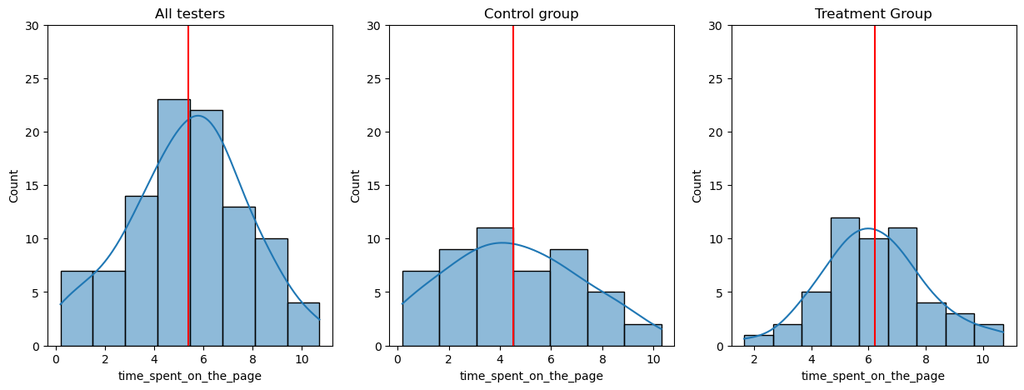

```python
fig, ax = plt.subplots(1, 3, figsize=(15, 5))

sns.histplot(data=abtest, x='time_spent_on_the_page', kde=True, ax=ax[0])
ax[0].axvline(abtest['time_spent_on_the_page'].mean(), c = "r")
ax[0].set_ylim(0, 30)
ax[0].set_title('All testers')

sns.histplot(data=data_oldpage, x='time_spent_on_the_page', kde=True, ax=ax[1])
ax[1].axvline(data_oldpage['time_spent_on_the_page'].mean(), c = "r")
ax[1].set_ylim(0, 30)
ax[1].set_title('Control group')

sns.histplot(data=data_newpage, x='time_spent_on_the_page', kde=True, ax=ax[2])
ax[2].axvline(data_newpage['time_spent_on_the_page'].mean(), c = "r")
ax[2].set_ylim(0, 30)
ax[2].set_title('Treatment Group')
```

```python
print('Total time spent on old page = ' + str(data_oldpage['time_spent_on_the_page'].sum()) + ' mins')
print('Avg time spent on old page = ' + str(data_oldpage['time_spent_on_the_page'].mean()) + ' mins')
print('Total time spent on new page = ' + str(data_newpage['time_spent_on_the_page'].sum()) + ' mins')
print('Avg time spent on new page = ' + str(data_newpage['time_spent_on_the_page'].mean()) + ' mins')
```

```
Total time spent on old page = 226.62000000000003 mins
Avg time spent on old page = 4.532400000000001 mins
Total time spent on new page = 311.16 mins
Avg time spent on new page = 6.2232 mins
```

- *The treatment group is **almost evenly distributed** with **very little skewness***. Hence it is **more normally distributed** than the control group.
- *The treatment group mean time spent on page is about **6.22 mins** and the total time is **311.16 mins***
- *The control group mean time spent on page is about **4.53 mins** and the total time is **226.62 mins***

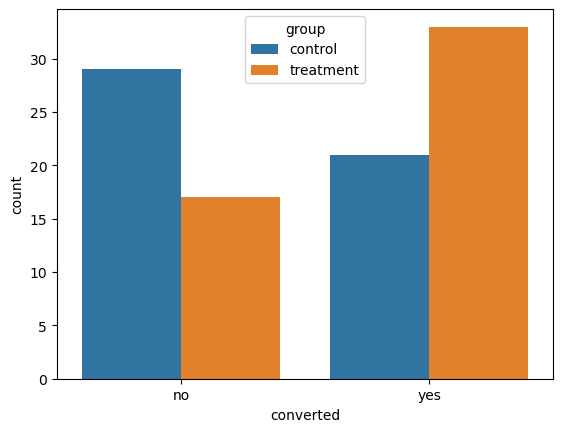

```python
sns.countplot(data=abtest, x='converted', hue='group')
```

```python
data_oldpage['converted'].value_counts(normalize=True)
```

```
converted
no     0.58
yes    0.42
Name: proportion, dtype: float64
```

```python
data_newpage['converted'].value_counts(normalize=True)
```

```
converted
yes    0.66
no     0.34
Name: proportion, dtype: float64
```

- *The conversion rate is **higher for new landing page** (66%) than the old landing page(42%)

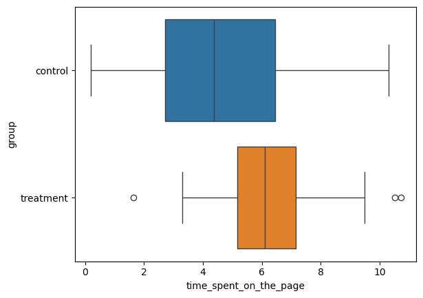

```python
sns.boxplot(data=abtest, x='time_spent_on_the_page', y='group', hue='group')
```

- *There are **3 outliers** seen in the treatment group*
- *The **median time spent on the new landing page is greater** than the median time spent on the old landing page*

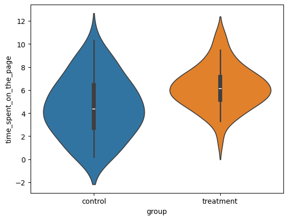

```python
sns.violinplot(data=abtest, x='group', y='time_spent_on_the_page', hue='group', orient='v')
```

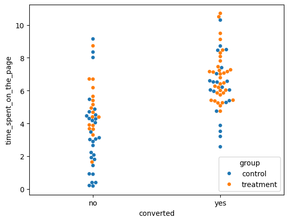

```python
sns.swarmplot(data=abtest, x='converted', y='time_spent_on_the_page', hue='group')
```

- *A very high proportion of users who spent **>4 min on the new landing page got converted** to subscribers*

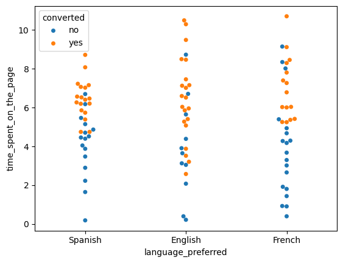

```python
sns.swarmplot(data=abtest, x='language_preferred', y='time_spent_on_the_page', hue='converted')
```

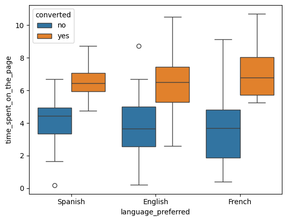

```python
sns.boxplot(data=abtest, x='language_preferred', y='time_spent_on_the_page', hue='converted')
```

- **Users who spent more time in general on the landing pages got converted**. The same trend is seen across groupings of all preferred languages

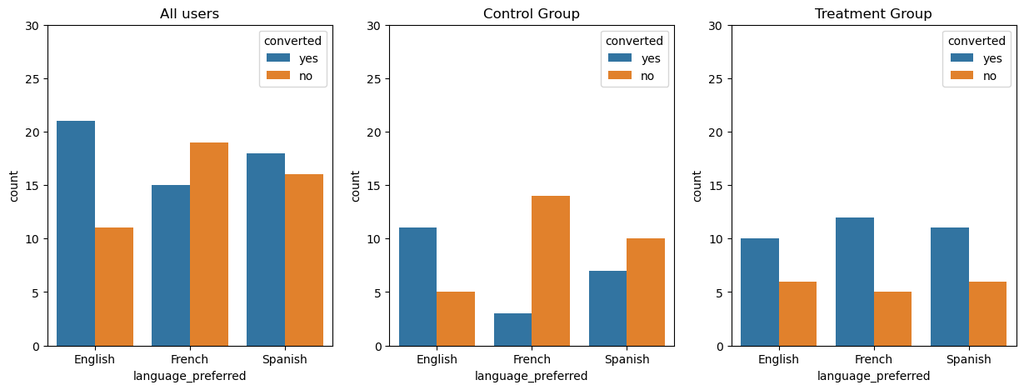

```python
fig, ax = plt.subplots(1, 3, figsize=(15, 5))

sns.countplot(data=abtest.sort_values("language_preferred", ascending = True), x='language_preferred', hue='converted', ax=ax[0])
ax[0].set_ylim(0, 30)
ax[0].set_title('All users')
sns.countplot(data=data_oldpage.sort_values("language_preferred", ascending = True), x='language_preferred', hue='converted', ax=ax[1])
ax[1].set_ylim(0, 30)
ax[1].set_title('Control Group')
sns.countplot(data=data_newpage.sort_values("language_preferred", ascending = True), x='language_preferred', hue='converted', ax=ax[2])
ax[2].set_ylim(0, 30)
ax[2].set_title('Treatment Group')
```

- *Users preferring Spanish and French did not show much interest in converting to subscribers on the old landing page*
- *However, **users of all languages opted to convert to the new landing page***

## Do the users spend more time on the new landing page than the old landing page?

### Visual analysis

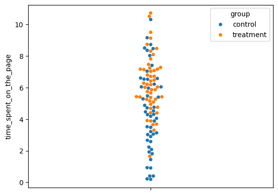

```python
sns.swarmplot(data=abtest, y='time_spent_on_the_page', hue='group')
```

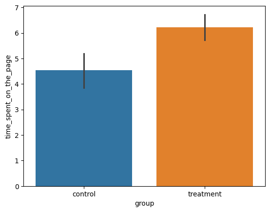

```python
sns.barplot(data=abtest, x='group', y='time_spent_on_the_page', hue='group')
```

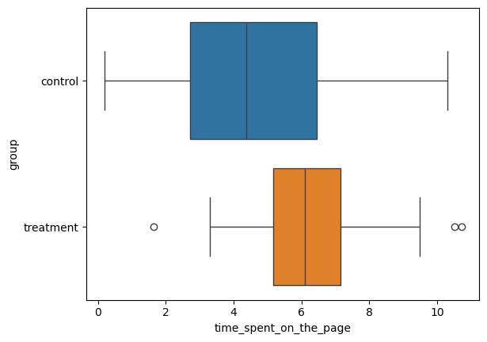

```python
sns.boxplot(data=abtest, x='time_spent_on_the_page', y='group', hue='group')
```

**Observation:** *Users seem to spend more time on the new landing page compared to the old landing page*

- *The swarm plot indicates a higher concentration of treatment group dots at a level higher than many of the control group dots*
- *The box plots and bar plots also show higher times for new landing page than old landing page*

### Null and Alternate hypothesis

Let $\mu_1$ and $\mu_2$ be the mean times spent on the new and old landing pages respectively.

> $H_0: \mu_1 = \mu_2$ (The mean time spent on the new landing page and the old landing page are the same)

> $H_a: \mu_1 > \mu_2$ (The mean time spent on the new landing page is greater than the mean time spent on the old landing page)

### Test selection

```python
print("The std dev of treatment group time:", data_newpage['time_spent_on_the_page'].std())
print("The std dev of control group time:", data_oldpage['time_spent_on_the_page'].std())
```

```
The std dev of treatment group time: 1.8170310387878263
The std dev of control group time: 2.581974849306046
```

- *The test is concerned with analysis run on only one variable time_spent_on_the_page - **Univariate analysis***
- *The test is concerned with **2 independent samples***
- *The times are measured on a continuous scale - **continuous distribution***
- *The sample size is 50 (>=30) and hence we can use the Central Limit Theorem's **normal distribution** for the sample means*
- *The population variance is unknown - **t-test***
- *The problem statement indicates 'random selection of users' - **random sampling***
- *This is a check for **equality of means***
- *The std devs are **unequal** and not close to each other*

Hence the most appropriate statistical test is **independent 2-sample t-test with unequal std dev**

### p-value calculation and comparison with level of significance(α)

```python
from scipy.stats import ttest_ind

stat, pvalue = ttest_ind(data_newpage['time_spent_on_the_page'], data_oldpage['time_spent_on_the_page'], equal_var=False, alternative='greater')
print('p-value = ', pvalue)
```

```
p-value =  0.0001392381225166549
```

**The p-value is < (α=0.05)**

### Inference

- *Due to the above, **there is enough statistical evidence to reject the null hypothesis.***
- *Hence at a 5% level of significance, it is inferred that **users spend more time on the new landing page (treatment group) than the old landing page (control group)***

## Is the conversion rate (the proportion of users who visit the landing page and get converted) for the new page greater than the conversion rate for the old page?

### Visual analysis

```python
abtest[abtest['group'] == 'treatment']['converted'].value_counts(normalize=True)
```

```
converted
yes    0.66
no     0.34
Name: proportion, dtype: float64
```

```python
abtest[abtest['group'] == 'control']['converted'].value_counts(normalize=True)
```

```
converted
no     0.58
yes    0.42
Name: proportion, dtype: float64
```

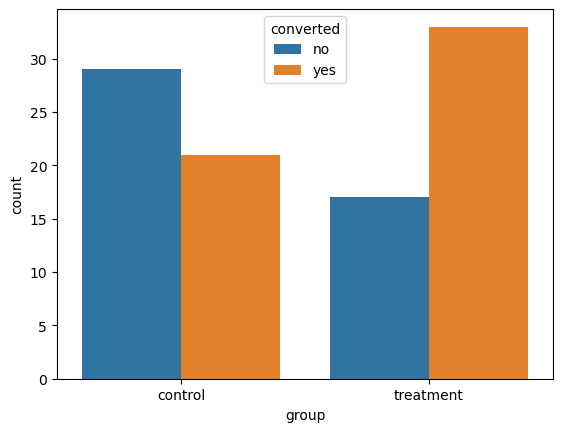

```python
sns.countplot(data=abtest, x='group', hue='converted')
```

- *Conversion rate of treatment group is **66%** which is much higher than the conversion rate of the control group which is **42%***

### Null and Alternate hypothesis

Let $p_1$ and $p_2$ be the proportion of converted users on the new and old landing pages repectively

> $H_0: p_1 = p_2$ (proportion of converted users on the new landing page and the old landing page are the same)

> $H_a: p_1 > p_2$ (proportion of converted users on the new landing page is greater than proportion of converted users on the old landing page)

### Test selection

- *The test is concerned with analysis run on one variable 'converted' - **Univariate analysis***
- *The test is concerned with **2 independent samples***
- *The 'converted' variable can take only 2 states (Y or N) - **binomial distribution***
- *The problem statement indicates 'random selection of users' - **random sampling***
- *This is a check for **proportions***

```python
n=50

print("np1 = ", len(data_newpage[data_newpage['converted'] == 'yes']))
print("n(1-p1) = ", len(data_newpage[data_newpage['converted']== 'no']))
print("np2 = ", len(data_oldpage[data_oldpage['converted']== 'yes']))
print("n(1-p2) = ", len(data_oldpage[data_oldpage['converted']== 'no']))
```

```
np1 =  33
n(1-p1) =  17
np2 =  21
n(1-p2) =  29
```

- **All of the above values > 10**

Hence the most appropriate statistical test is **Two proportions z-test**

### p-value calculation and comparison with level of significance(α)

```python
from statsmodels.stats.proportion import proportions_ztest

converted_count = np.array([len(data_newpage[data_newpage['converted'] == 'yes']), len(data_oldpage[data_oldpage['converted']== 'yes'])])
nobs = np.array([n, n])

stat, pvalue = proportions_ztest(converted_count, nobs, alternative='larger')
print('p-value = ', pvalue)
```

```
p-value =  0.008026308204056278
```

***The p-value is < (α=0.05)***

### Inference

- *Due to the above, **there is enough statistical evidence to reject the null hypothesis.***
- *Hence at a 5% level of significance, it is inferred that **proportion of converted users on the new landing page (treatment group) is greater than proportion of converted users on the old landing page (control group)***
- *Rephrased - **The conversion rate of new landing page is higher than the old landing page***
- *This has already been proved above using the countplot using visual analysis*

## Does the converted status depend on the preferred language?

### Visual analysis

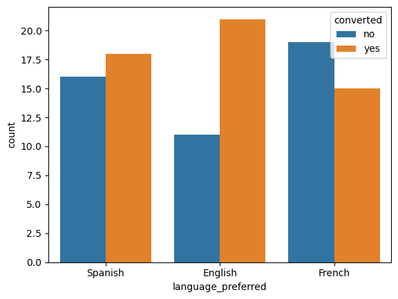

```python
sns.countplot(data=abtest, x='language_preferred', hue='converted')
```

- *French users have the lowest conversion rate*

### Null and Alternate hypothesis

> $H_0:$Conversion status is independent of the preferred language

> $H_a:$Conversion status is dependent of the preferred language

### Test selection

- *The test is concerned with analysis run on two variables 'converted' and 'preferred_language' - **Bivariate analysis***
- *Both variables are **categorical***
- *The problem statement indicates 'random selection of users' - **random sampling***
- *This is a check for **independence** of variables*
- **Number of observations > 5** for all cases as proven by the countplot above

Hence the most appropriate statistical test is **Chi-square test for independence**

### p-value calculation and comparison with level of significance(α)

```python
from scipy.stats import chi2_contingency

#creation of a contingency table
cont_table = pd.crosstab(abtest['converted'], abtest['language_preferred'])
cont_table
```

| language_preferred converted | English | French | Spanish |
| --- | --- | --- | --- |
| no | 11 | 19 | 16 |
| yes | 21 | 15 | 18 |

```python
chi2_contingency(cont_table)
```

```
Chi2ContingencyResult(statistic=3.0930306905370837, pvalue=0.21298887487543447, dof=2, expected_freq=array([[14.72, 15.64, 15.64],
       [17.28, 18.36, 18.36]]))
```

**The p-value is > (α=0.05)**

### Inference

- *Due to the above, **there is NOT enough statistical evidence to reject the null hypothesis***
- *Hence at a 5% level of significance, it is inferred that **Conversion status is independent of the preferred language***

## Is the mean time spent on the new page same for the different language users?

### Visual analysis

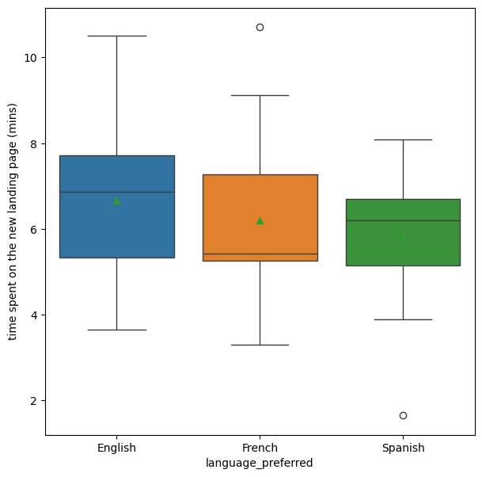

```python
plt.figure(figsize=(7,7))
sns.boxplot(x="language_preferred", y="time_spent_on_the_page",\
            data=data_newpage.sort_values("language_preferred", ascending = True), hue='language_preferred', showmeans=True);
plt.ylabel("time spent on the new landing page (mins)")
plt.show()
```

- *English users spent the maximum amount of time on the new page, followed by French and Spanish users*
- *There is one outlier each for the French and Spanish users*

### Null and Alternate hypothesis

Let μ1, μ2, μ3 be the mean time spent on the new landing page for the different language users - English, French and Spanish respectively.

$H_0: \mu_{1} = \mu_{2} = \mu_{3} $

$H_a$: Atleast one of $\mu_{1}, \mu_{2}$, or $\mu_{3}$ is different from the rest

### Test selection

- *This is a comparison of means of **more than 2 populations***
- *The test is concerned with analysis run on two variables 'time_spent_on_the_page' and 'preferred_language' - **Bivariate analysis***
- *'time_spent_on_the_page' is a **continuous variable** and 'language_preferred' is a **discrete variable***
- *The problem statement indicates 'random selection of users' - **random sampling***

Hence the most appropriate statistical test is **One-way ANOVA f-test**

We need to confirm the following 2 conditions for f-test:

- *Shapiro-Wilk's test for normality*
- *Levene's test for variance equality*

#### Shapiro-Wilk's test

##### Hypothesis

> $H_0:$time_spent_on_the_page follows a normal distribution

> $H_a:$time_spent_on_the_page does not follow a normal distribution

```python
from scipy.stats import shapiro

stat, pvalue = shapiro(data_newpage['time_spent_on_the_page'])
print('p-value = ', pvalue)
```

```
p-value =  0.8040040364746845
```

**The p-value is > (α=0.05)**

- *Due to the above, **there is NOT enough statistical evidence to reject the null hypothesis.***
- *Hence at a 5% level of significance, it is inferred that **time_spent_on_the_page follows a normal distribution***

#### Levene's test

##### Hypothesis

> $H_0:$The variances of all populations for different languages are equal

> $H_a:$Atleast one population variance is different

```python
from scipy.stats import levene

pop1 = data_newpage[data_newpage['language_preferred'] == 'English']['time_spent_on_the_page']
pop2 = data_newpage[data_newpage['language_preferred'] == 'Spanish']['time_spent_on_the_page']
pop3 = data_newpage[data_newpage['language_preferred'] == 'French']['time_spent_on_the_page']
stat, pvalue = levene(pop1, pop2, pop3)
print('p-value = ', pvalue)
```

```
p-value =  0.46711357711340173
```

**The p-value is > (α=0.05)**

- *Due to the above, **there is NOT enough statistical evidence to reject the null hypothesis.***
- *Hence at a 5% level of significance, it is inferred that **the variances of all populations for different languages are equal***

Both the conditions for the f_test are satisfied. Hence we can proceed forward with the **One-way ANOVA f-test**

### p-value calculation and comparison with level of significance(α)

```python
from scipy.stats import f_oneway
stat, pvalue = f_oneway(pop1, pop2, pop3)
print('p-value = ', pvalue)
```

```
p-value =  0.43204138694325955
```

**The p-value is > (α=0.05)**

### Inference

- *Due to the above, **there is NOT enough statistical evidence to reject the null hypothesis***
- *Hence at a 5% level of significance, it is inferred that **the mean time spent on the new landing page for the different language users is the same***

## Conclusion and Business Recommendation

#### Conclusions

At a (α=0.05) level of significance

1. Users spend more time on the new landing page than the old landing page
2. The conversion rate of new landing page is higher than the old landing page
3. Conversion status is independent of the preferred language
4. The mean time spent on the new landing page for the different language users is the same

#### Recommendations

1. E-news Express should introduce the new landing page. Based on statistical evidence, the time spent by users on the new landing page is more than on the old landing page. The conversion rate has also been proved to be higher on the new landing page
2. As there is no significant evidence of the conversion status with respect to languages, the new landing page can be introduced to all users irrespective of language
3. E-new Express should try to introduce the new landing page to other language users as well and carry out statistical tests on relationships of attributes with the language